# qqplot

Bingquan Wu

October 30, 2018

## qqplot introduction

In statistics, a Q-Q (quantile-quantile) plot is a probability plot, which is a graphical method for comparing two probability distributions by plotting their quantiles against each other.[1]A point (x, y) on the plot corresponds to one of the quantiles of the second distribution (y-coordinate) plotted against the same quantile of the first distribution (x-coordinate). Thus the line is a parametric curve with the parameter which is the number of the interval for the quantile.[2]

## normal or not (examples using qqnorm)

Examples of a normal qqplot

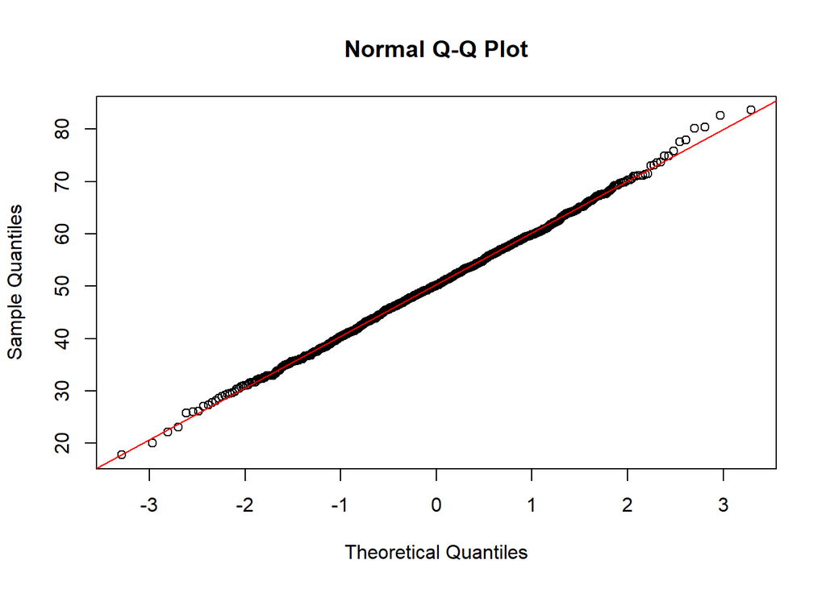

```r
x <- rnorm(1000, 50, 10)
qqnorm(x)
qqline(x, col = "red")
```

The points seem to fall about a straight line. Notice the x-axis plots the theoretical quantiles. Those are the quantiles from the standard Normal distribution with mean 0 and standard deviation 1.[3]

Examples of a not normal qqplot

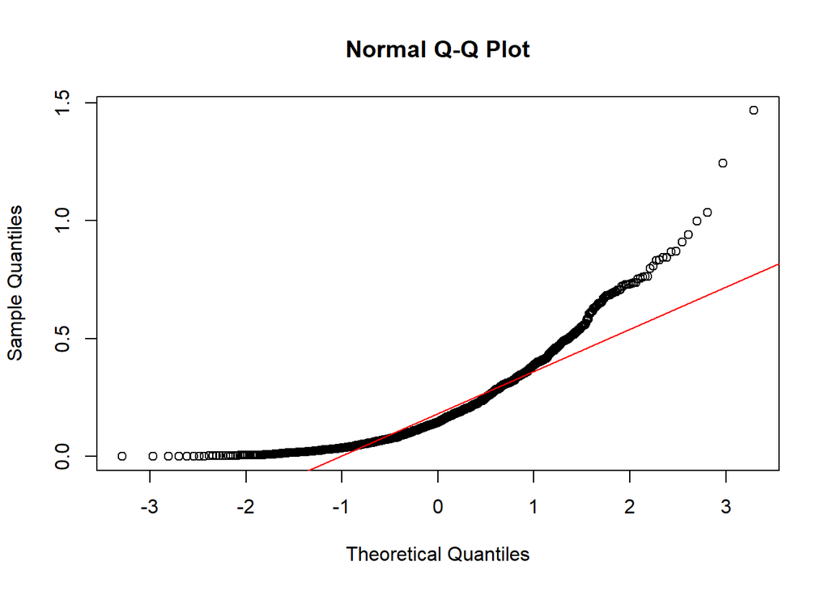

```r
x <- rexp(1000, 5)
qqnorm(x)
qqline(x, col = "red")
```

Notice the points form a curve instead of a straight line. Normal Q-Q plots that look like this usually mean your sample data are skewed.[3]

## different kinds of qqplot

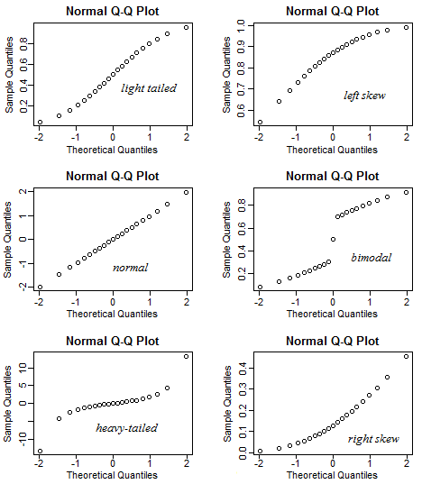

Different kinds of qqplot

## qqplot using ggplot

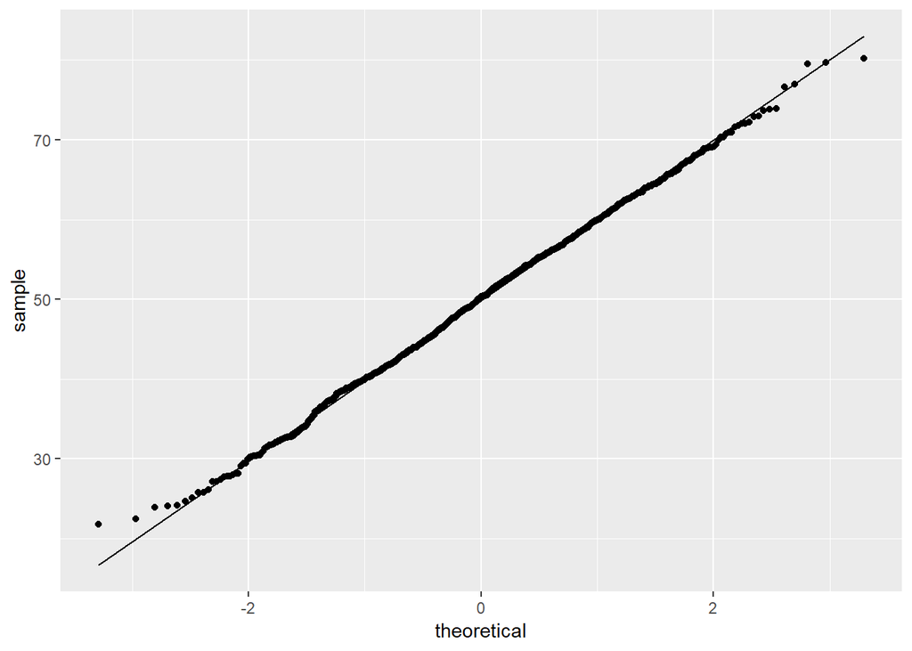

```r
library(ggplot2)
x <- rnorm(1000, 50, 10)
x <- data.frame(x)
ggplot(x, aes(sample = x)) +
  stat_qq() +
  stat_qq_line()
```

In order to use ggplot2 to plot qqplot, we must use a dataframe, so here we conert it to the dataframe  
We can see that using ggplot to plot a ggplot has a similar outcome as using qqnorm

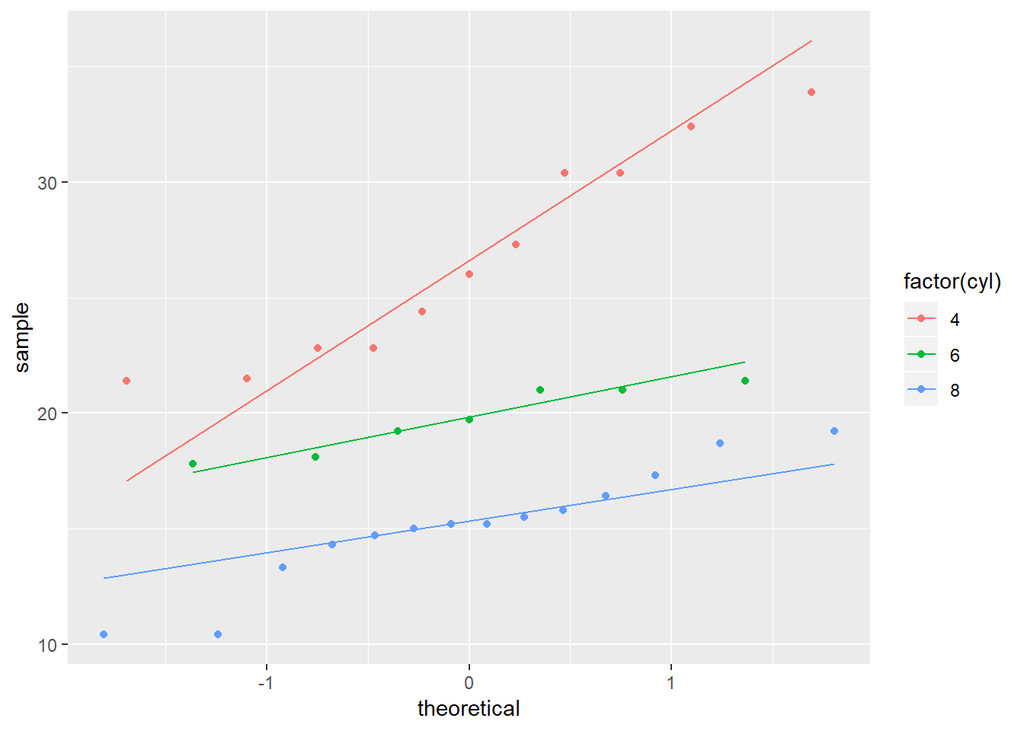

```r
library(ggplot2)
ggplot(mtcars, aes(sample = mpg, colour = factor(cyl))) +
  stat_qq() +
  stat_qq_line()
```

However when we need to plot different group, ggplot will be very helpful, with different color by factor.

## reference

[1] Wilk, M.B.; Gnanadesikan, R. (1968), “Probability plotting methods for the analysis of data”, Biometrika, Biometrika Trust  
[2] Wiki, QQplot - https://en.wikipedia.org/wiki/Q%E2%80%93Q_plot#cite_note-1\ [3] Understanding Q-Q Plots https://data.library.virginia.edu/understanding-q-q-plots/\ [4] How to interpret a QQ plot https://stats.stackexchange.com/questions/101274/how-to-interpret-a-qq-plot\ [5] modules BIOL30030, BIOL40390 and ENVB40370 Dr Jon Yearsley (School of Biology and Environmental Science, UCD)  
[6] A QQ Plot Dissection Kithttp://seankross.com/2016/02/29/A-Q-Q-Plot-Dissection-Kit.html